# TS_S2023_F

## Libraries

For this exam you are going to require the following packages. If you do not have either of them installed, install them before loading them.

```r
# Load packages
library(readxl)
library(fpp3)
library(patchwork)
```

## Dataset

For this exam we are going to use the following dataset:

1. `usgas_y_m`: this dataset contains information about the monthly gas consumption in the US for different purposes and states.

To load the dataset, you may run the code below. This will open a pop-up window. Select the excel file and it will be loaded as a tsibble to `usgas_y_m`. The variables will be:

Below a description of the columns: * `process:` purpose for which the gas was consumed. * `state:` state of the data point. * `y_m`: yearmonth object detailing the year and the month of the observation. It is the index of the tsibble * `monthly_gas:` amount of gas consumed by the particular process at the particular state in the given month. **Units:** Million Cubic Feet (`MMCF`)

```r
usgas_y_m <-
  read_xlsx(file.choose()) %>%
    mutate(
      y_m = yearmonth(date)
    ) %>%
    as_tsibble(
      key=c(state, process),
      index = y_m
    ) %>%
    select(process, state, y_m, monthly_gas)

colnames(usgas_y_m)
```

```r
usgas_y_m <-
  read_xlsx("usgas_y_m.xlsx") %>%
    mutate(
      y_m = yearmonth(date)
    ) %>%
    as_tsibble(
      key=c(state, process),
      index = y_m
    ) %>%
    select(process, state, y_m, monthly_gas)
```

## 1. 0.5 points

1. How many different time series does the loaded object usgas_y_m contain?

**HINT:** a possible way to check the unique combinations of two columns in a tibble/dataframe is using `dplyr`’s function distinct in combination with `nrow()` to count the number of rows. For example, the code below counts the number of unique combinations of the columns `col1` and `col2` in the toy dataframe `df_toy` provided:

```r
df_toy <- tibble(
  col1 = c("a", "b", "a", "b", "a"),
  col2 = c("x", "y", "x", "y", "z"),
  col3 = c(1, 2, 1, 2, 3)
)

# Count the number of unique combinations of col1 and col2 values:
n_distinct <- df_toy %>%
                distinct(col1, col2) %>%
                nrow()

# Number of unique combinations of col1 and col2
n_distinct
```

```
[1] 3
```

```r
usgas_y_m %>%
  distinct(process, state) %>%
  nrow()
```

```
[1] 250
```

## 2. 0.5 points

For the process `Vehicle Fuel Consumption`, we would like to examine the state with the greatest consumption every year. To compute this:

1. Create a new column `year` from the variable `y_m`
2. Use `group_by()` appropriately to compute the total gas consumed by each state, for each process, each year. Store this result as `usgas_y`
3. Starting from `usgas_y`, filter for the process *Vehicle Fuel Consumption* and use `group_by()` again appropriately to have a final dataset with only one row per year: the row corresponding to the state with the greatest consumption of gas for *Vehicle Fuel Consumption*.

```r
usgas_y <-
  usgas_y_m %>%
    mutate(year = year(y_m)) %>%
    as_tibble() %>%
    group_by(state, process, year=year(y_m)) %>%
    summarize(
      yearly_gas = sum(monthly_gas)
    ) %>%
    ungroup()
max_vehicle_gas_y <-
  usgas_y %>%
  filter(process == "Vehicle Fuel Consumption") %>%
  group_by(process, year) %>%
  filter(
    yearly_gas == max(yearly_gas)
  )
```

# 3. 2 points

From now on we are going to focus on the state of California and the process *Vehicle Fuel Consumption*. Filter the dataset `usgas_y_m` accordingly and store the result in a variable called `cali_fuel_y_m`.

Plot the time series indicating at least the beginning of every year:

```r
cali_fuel_y_m <-
  usgas_y_m %>%
  filter(state == "California", process == "Vehicle Fuel Consumption")
```

```
Plot variable not specified, automatically selected `.vars = monthly_gas`
```

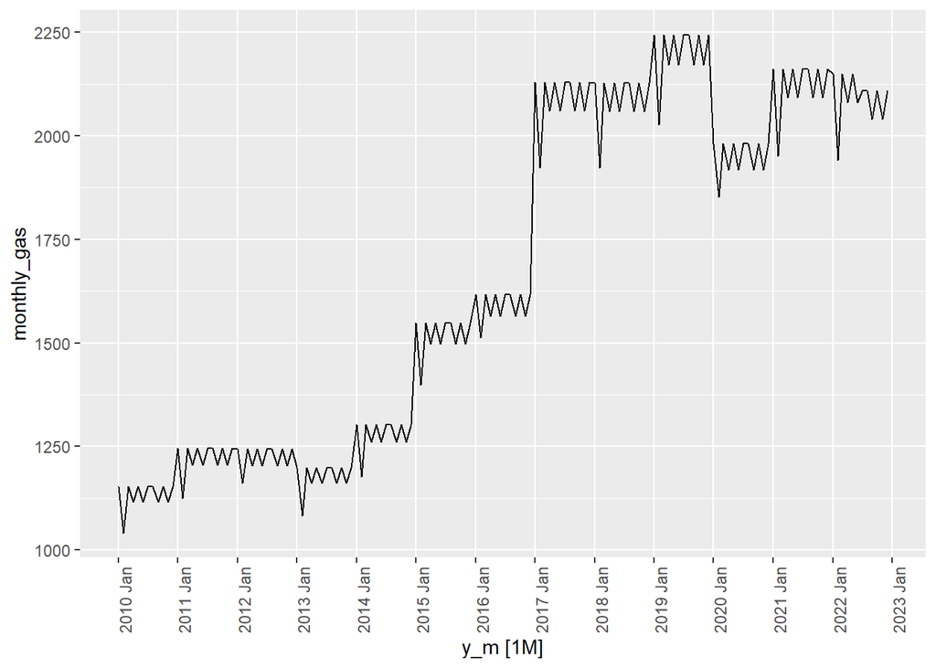

```r
cali_fuel_y_m %>%
  autoplot() +
  scale_x_yearmonth(breaks="1 year", minor_breaks="1 year") +
  theme(axis.text.x = element_text(angle = 90))
```

# 4. 1 point

Looking at the previous graph and at the value suggested for lambda using the `guerrero` method, judge if a transformation to balance the variance of the time series with the level of the time series is necessary:

```r
lambda <-
  cali_fuel_y_m %>%
    features(monthly_gas, features = guerrero) %>%
    pull(lambda_guerrero)
```

```r
The value of lambda is very close to 0, which would indicate that a log transformation
could be sensible. However, if we look at the time plot it appears that the variance
of the time series does not necessarily increase with the level of the series.

There is a sudden change in the level of the series at the end of some specific
years which seems to be driven by some external factors (policy changes...) but
does not affect the variance of the time series.

Since we are unsure whether a log transformation would bring significant improvements
we will fit models with and without transformation and then evaluate the results.
```

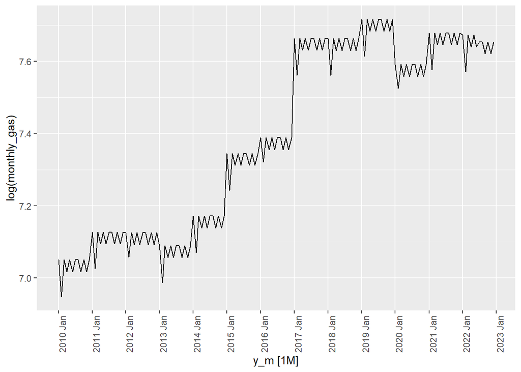

```r
cali_fuel_y_m %>%
  autoplot(log(monthly_gas)) +
  scale_x_yearmonth(breaks="1 year", minor_breaks="1 year") +
  theme(axis.text.x = element_text(angle = 90))
```

# 5. 2 points

Starting from `cali_fuel_y_m`, create a series of taining datasets for cross validation that fulfil:

1. The smallest of these training datasets shall contain 60% of the dataset.
2. The datasets shall increase in steps of 3 (three months at a time).

```r
cali_fuel_y_m <-
  usgas_y_m %>%
  filter(state=="California") %>%
  filter(process=="Vehicle Fuel Consumption")

# Compute parameters for the CV train-test split
init_perc <-  0.6
step <-  3
init_size <-  ceiling(nrow(cali_fuel_y_m)*init_perc)


cali_fuel_y_m_cv <-
  stretch_tsibble(cali_fuel_y_m, .init=init_size, .step=step)
```

Then answer these questions:

Q1: How many datasets have we generated?

```r
max_id <- cali_fuel_y_m_cv$.id %>% max()
```

Q2: What are the sizes (in number of observations) of the smallest and biggest trainingn dataset?

```r
cali_fuel_y_m_cv %>%
  as_tibble() %>%
  group_by(.id) %>%
  summarize(
    size = n()
  ) %>%
  filter(.id == 1 | .id==max_id)
```

```
# A tibble: 2 × 2
    .id  size
  <int> <int>
1     1    94
2    21   154
```

# 6. 2 points

Fit the following models to the training datasets:

1. `decomposition_model` applying an STL decomposition and a log transformation. Use a
   - drift model for the seasonally adjusted component
   - a seas. naïve model for the seasonal component.
2. `decomposition_model` applying an STL decomposition and no transformation. Use a
   - drift model for the seasonally adjusted component
   - a seas. naïve model for the seasonal component.
3. `decomposition_model` applyting an STL decomposition and a log transformation. Use a:
   - SES (Simple Exp. Smoothing) model for the seasonally adjusted component
   - a seas. naïve model for the seasonal component.
4. `decomposition_model` applyting an STL decomposition with no transformation. Use a:
   - SES (Simple Exp. Smoothing) model for the seasonally adjusted component
   - a seas. naïve model for the seasonal component.
5. An SES (Simple) exponential smoothing model
6. A Naive model

**Do not spend time looking for the best parameters of an STL decomposition, use the default arguments of the STL decomposition**

After having fitted the models, perform **one year ahead forecasts**.

```r
fit_cv <-
  cali_fuel_y_m_cv %>%
    model(
      dcmp_log_drift = decomposition_model(
                 # Specify decomposition scheme to be used
                 STL(log(monthly_gas)),
                 # Specify model for the seasonally adjusted component
                 RW(season_adjust ~ drift()),
                 # Specify model for the seasonal component (unnecessary since SNAIVE is default)
                 SNAIVE(season_year)
                 ),
      dcmp_drift = decomposition_model(
                 # Specify decomposition scheme to be used
                 STL(monthly_gas),
                 # Specify model for the seasonally adjusted component
                 RW(season_adjust ~ drift()),
                 # Specify model for the seasonal component (unnecessary since SNAIVE is default)
                 SNAIVE(season_year)
                 ),
      dcmp_log_ses = decomposition_model(
                 # Specify decomposition scheme to be used
                 STL(log(monthly_gas)),
                 # Specify model for the seasonally adjusted component
                 ETS(season_adjust ~ error("A") + trend("N") + season("N")),
                 # Specify model for the seasonal component (unnecessary since SNAIVE is default)
                 SNAIVE(season_year)
                 ),
      dcmp_ses = decomposition_model(
                 # Specify decomposition scheme to be used
                 STL(monthly_gas),
                 # Specify model for the seasonally adjusted component
                 ETS(season_adjust ~ error("A") + trend("N") + season("N")),
                 # Specify model for the seasonal component (unnecessary since SNAIVE is default)
                 SNAIVE(season_year)
                 ),
      ses = ETS(monthly_gas ~ error("A") + trend("N") + season("N")),
      naive = NAIVE(monthly_gas)
    )
```

```r
fc_cv <-
  fit_cv %>%
    forecast(h = 12)
```

```r
summary_cv_errors <-
  fc_cv %>%
  accuracy(cali_fuel_y_m) %>%
  select(.model, RMSE, MAE, MAPE) %>%
  arrange(RMSE)
summary_cv_errors
```

```
# A tibble: 6 × 4
  .model          RMSE   MAE  MAPE
  <chr>          <dbl> <dbl> <dbl>
1 dcmp_ses        118.  83.1  4.04
2 ses             120.  87.8  4.29
3 naive           122.  82.4  4.04
4 dcmp_log_ses    123.  88.0  4.27
5 dcmp_drift      135.  77.4  3.83
6 dcmp_log_drift  154.  88.6  4.37
```

Subsequently, examine which model has best forecasting performance in terms of RMSE. Compute the average RMSE over all the forecast horizons.

```r
Looking at the table, the model with a smallest RMSE is the decomposition model
using an SES model for the seasonally adjusted component.
```

Then answer:

1. Do the transformations bring any significant improvement?.

```r
The accuracy metrics for the models with transformation are not significantly better.
What is more, the models with transformations present greater values of these
metrics, indicating that no significant improvement has been attained.
```

2. Which model would you pick for forecasting? (again, based on the RMSE).

```r
Looking at the table, the model with a smallest RMSE is the decomposition model
using an SES model for the seasonally adjusted component.
```

# 7. 2 points

For the decomposition model using SES for the seasonally adjusted component and no transformation:

1. Fit the model to the entirety of the time series, without splitting it.

```r
fit <-
  cali_fuel_y_m %>%
  model(
      dcmp_ses = decomposition_model(
                 # Specify decomposition scheme to be used
                 STL(monthly_gas),
                 # Specify model for the seasonally adjusted component
                 ETS(season_adjust ~ error("A") + trend("N") + season("N")),
                 # Specify model for the seasonal component (unnecessary since SNAIVE is default)
                 SNAIVE(season_year)
                 )
  )
```

2. Analyze the residuals of the model. Do this **bases solely on the output of gg_tsresiduals()**

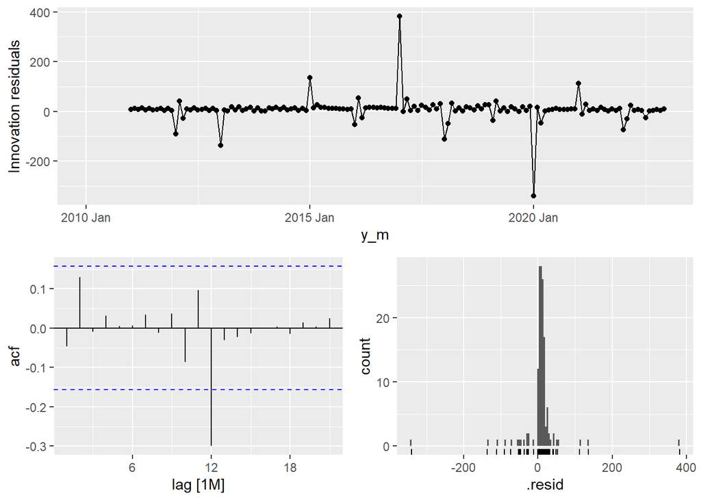

```r
fit %>%
  gg_tsresiduals()
```

| Your answer goes here (100 words max) |
| --- |

```r
1. Autocorrelation

The ACF plot clearly shows a strong autocorrelation at lag 12. Looking at the
time plot of the residuals, it seems to be related with the sharp changes in the
level of the time series at the end of specific years, which is not appropriately
captured by the model. That is why the residuals exhibit some larger values at
the beginning of some years.

Since these changes in the level of the series are driven by external factors,
modelling them would involve including external variables (something we will see
in the next course).
```

```r
fit %>% augment() %>% pull(.innov) %>% mean(na.rm=TRUE)
```

```
[1] 7.277193
```

```r
2. 0-Mean

Graphially, the mean seems to be close to 0. However if we compute it we see
that it departs from 0, indicating that there is a certain bias in the model.

We could remove this bias directly from the forecasts.
```

```r
3. Homoskeasticity

The residuals seem fairly homoskedastic with the exception of some local spikes
at the beginning/end of some years.

These are related to the changes in level experienced by the time series, which
are driven by external factors.

We could say that these residuals are homoskedastic with some local
heteroskedasticity.
```

```r
4. Normality

Looking at the output of ggtsresiduals the normality assumption does not seem
to hold.


For the sake of investigatinv a bit further (not requested in the exam), we may
produce a qq-plot and a box-plot. Looking at the strong departure from the qqplot
outside the central region and the spykiness of the distribution, we may conclude
that the distribution is strongly leptokurtic, deviating from normality.
```

```r
model_vals <- fit %>% augment()

# sample size
model_vals %>% nrow()
```

```
[1] 156
```

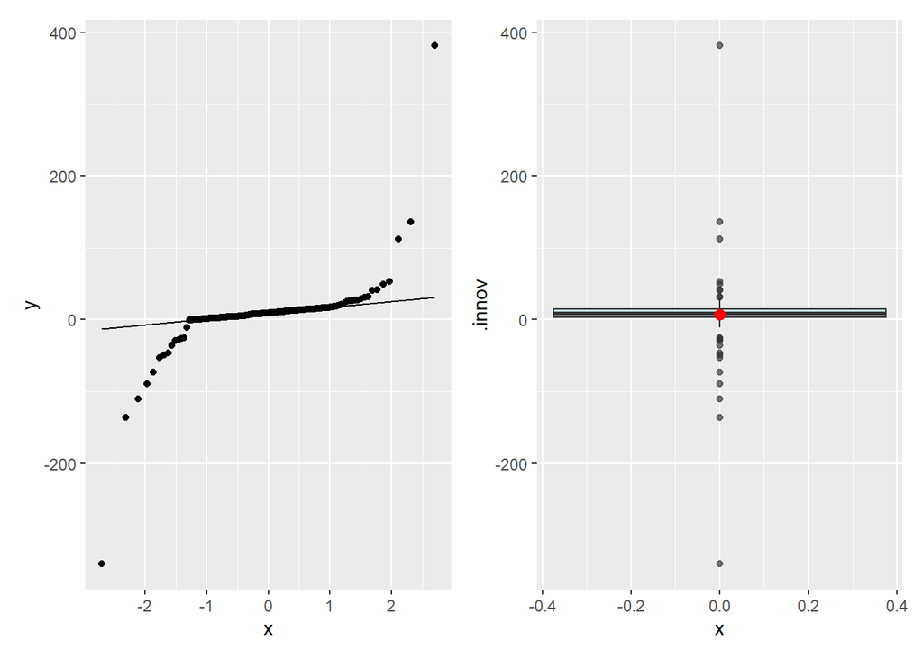

```r
# Generate qq_plot
p1 <- ggplot(model_vals, aes(sample = .innov))
p1 <- p1 + stat_qq() + stat_qq_line()

# Generate box-plot
p2 <- ggplot(data = model_vals, aes(y = .innov)) +
      geom_boxplot(fill="light blue", alpha = 0.7) +
      stat_summary(aes(x=0), fun="mean", colour= "red") # Include the mean

# library patchwork is required
p1 + p2
```